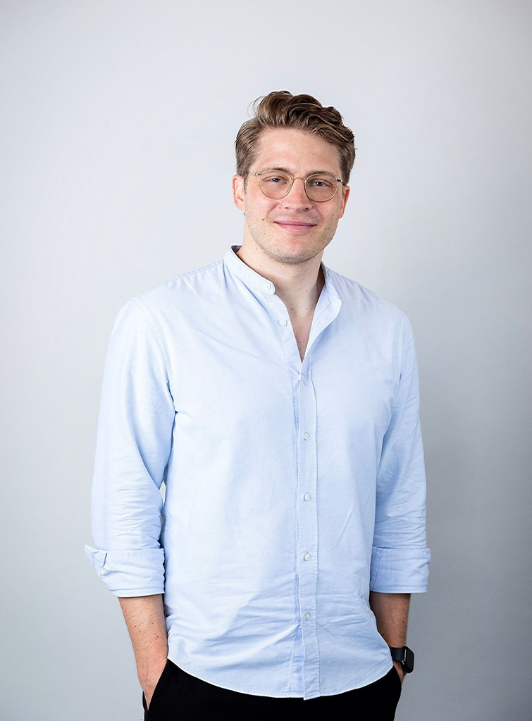

# Thomas Meissner

[Twitter](https://twitter.com/tgkmeissner) [BlueSky](https://bsky.app/profile/thomasmeissner.bsky.social) [Github](https://github.com/TGKMeissner) [Google Scholar](https://scholar.google.de/citations?user=Ja0JT1oAAAAJ&hl=en) meissnet {at} gmail.com

I am an Associate Professor of Economics at the Department of Microeconomics and Public Economics at Maastricht University.

My primary research interest lies in the fields of experimental and behavioral economics. I am particularly interested in how people make economic decisions that involve risk or intertemporal tradeoffs, such as behavior on financial markets or individual borrowing and saving decisions. To answer these questions I use theory-based laboratory experiments but also large-scale, representative studies to structurally estimate the effect of economic preferences on economic decisions.

Additionally, I work on belief elicitation, including a new method for eliciting parametric belief distributions, and have recently begun exploring the darker aspects of human behavior, such as exploitation.

Together with Peter Werner, I co-organize the annual [M-BEES and M-BEPS](https://m-bees.nl) symposia, which bring together researchers and practitioners in experimental and behavioral economics.

I am also principal investigator and co-founder of the [Dutch Business Panel](https://dutchbusinesspanel.nl/), a panel for studying the decisions and expectations of Dutch firms.

In 2018, I received the Marie Skłodowska-Curie Individual Fellowship for my research on debt aversion.